# act_report

## Report: act_report

## Introduction

### This report shows some insights and visuals from the data wrangling and analysis of the WeRateDogs twitter account.

### Insight 1

### Source of Tweet

#### The first insight of this analysis is to see the count of different sources where the tweeet was generated from.

#### We saw that most of the tweet came from Twitter for iPhone with a count of 2221, 91 from Vine, 33 from Twitter Web Client and 11 from Tweetdeck.

### Insight 2

### Dog stages according to likes

#### We for dog stages, the puppo stage has the highest number of likes with a count of 132810 followed by the doggos stage with a coount of 131075

### Insight 3

### Prediction of Dog stages according to prediction 1, 2 and 3

#### I wanted to see how true the dog predictions were considering they had three different predictions. In prediction 1, the doggo dog stage had 51 True predictions and 16 False predictions. When compared to prediction 2(52 True and 15 False), and prediction 3(47 True and 20 False), we can see that all the predictions are in the same range. The same thing goes for other dog stages.

#### There we can say that there was no need for prediction 2 and 3 as prediction 1 could have been enough for the data to determine how easily users could identify dog stages through the pictures.

### Visual 1

### Correlation between Favorite Count(Likes) and Retweet Count

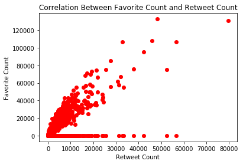

### Visual 2

### The Distribution of Dog Stages

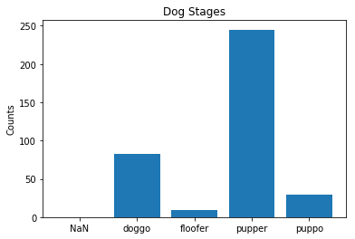